# Step Analysis - Reproducible Research Project 1

This is an analysis of data acquired from a personal activity monitoring device. The data are from one  
individual and has the following variables:

- **steps**: Number of steps taking in a 5-minute interval (missing values are coded as NA)
- **date**: The date on which the measurement was taken in YYYY-MM-DD format
- **interval**: Identifier for the 5-minute interval in which measurement was taken

There are a total of 17,568 observations in this dataset.

We will be using the following packages (we will suppress warnings to keep the html compact):

```r
suppressWarnings(suppressMessages(library(plyr)))
suppressWarnings(suppressMessages(library(dplyr)))
suppressWarnings(suppressMessages(library(data.table)))
suppressWarnings(suppressMessages(library(downloader)))
suppressWarnings(suppressMessages(library(xtable)))
suppressWarnings(suppressMessages(library(lubridate)))
suppressWarnings(suppressMessages(library(ggplot2)))
```

## Loading and preprocessing the data

Next we will load the data into a dataframe, rename and summarize.

```r
url <- "https://d396qusza40orc.cloudfront.net/repdata%2Fdata%2Factivity.zip"
download.file(url, "Steps_Dataset.zip")
unzip("Steps_Dataset.zip")
activity <- read.table('activity.csv', sep = ",", header = TRUE)
head(activity)
```

```
##   steps       date interval
## 1    NA 2012-10-01        0
## 2    NA 2012-10-01        5
## 3    NA 2012-10-01       10
## 4    NA 2012-10-01       15
## 5    NA 2012-10-01       20
## 6    NA 2012-10-01       25
```

## Mean total number of steps taken per day

First, let’s check the total number of steps per day.

```r
meancheck <- activity %>%
  group_by(date) %>%
  summarise(totaldaily = sum(steps, na.rm=TRUE))
```

Second, we will create a histogram of the total steps per day.

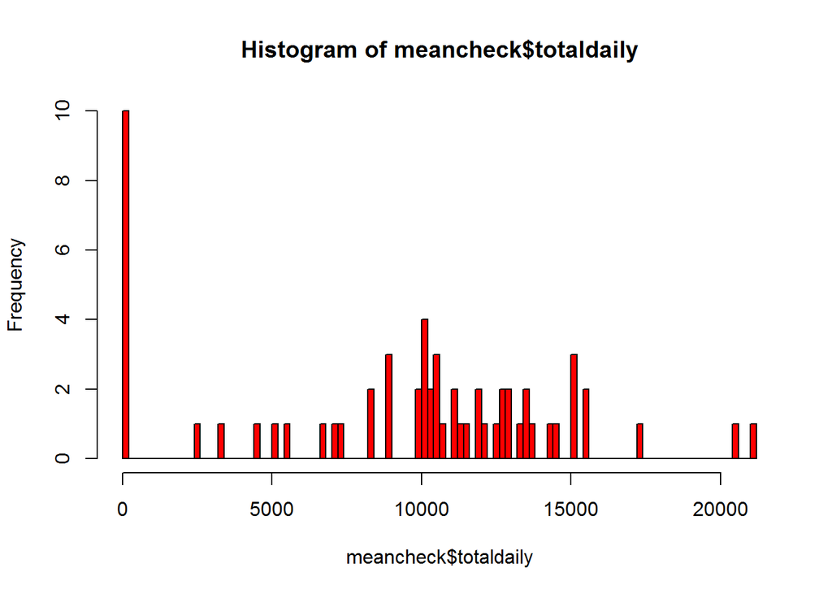

```r
meancheck$totaldaily <- as.numeric(meancheck$totaldaily)
hist(meancheck$totaldaily, breaks=100, col="red")
```

Finally, let’s calculate the mean and median

```r
mean_steps <- meancheck %>%
  summarise(mean_total = mean(totaldaily, na.rm=TRUE))
mean_steps
```

```
## # A tibble: 1 x 1
##   mean_total
##        <dbl>
## 1    9354.23
```

```r
median_steps <- meancheck %>%
  summarise(median_total = median(totaldaily, na.rm=TRUE))
median_steps
```

```
## # A tibble: 1 x 1
##   median_total
##          <dbl>
## 1        10395
```

## Average daily activity pattern

Here we will group by interval but also take the average across days while doing so.

```r
interval_steps <- activity %>%
  group_by(interval) %>%
  summarise(totaldaily = mean(steps, na.rm=TRUE))
interval_steps
```

```
## # A tibble: 288 x 2
##    interval totaldaily
##       <int>      <dbl>
## 1         0  1.7169811
## 2         5  0.3396226
## 3        10  0.1320755
## 4        15  0.1509434
## 5        20  0.0754717
## 6        25  2.0943396
## 7        30  0.5283019
## 8        35  0.8679245
## 9        40  0.0000000
## 10       45  1.4716981
## # ... with 278 more rows
```

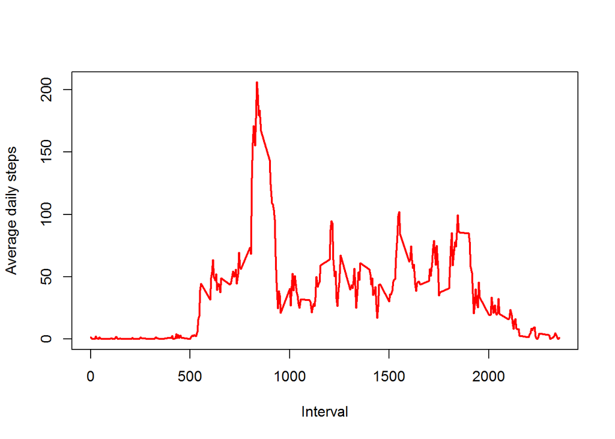

```r
plot(interval_steps$interval, interval_steps$totaldaily, type = "l",
     xlab="Interval", ylab="Average daily steps", col="red" , lwd=2)
```

And the maximum steps for an interval is:

```r
max_interval <- interval_steps[which(interval_steps$totaldaily == max(interval_steps$totaldaily, na.rm = TRUE)), ]
max_interval
```

```
## # A tibble: 1 x 2
##   interval totaldaily
##      <int>      <dbl>
## 1      835   206.1698
```

## Impute missing value

The total number of missing values is:

```r
nrow(activity[activity$steps == "NA",])
```

```
## [1] 2304
```

For imputation, We will use the average value for the interval across all days.

```r
impute.mean <- function(x) replace(x, is.na(x), mean(x, na.rm = TRUE))
activity_imp <- ddply(activity, ~ interval, transform, steps = impute.mean(steps))
activity_impord <- activity_imp[order(activity_imp$date), ]
nrow(activity_imp[activity_impord$steps == "NA",])
```

```
## [1] 0
```

And here is the new histogram as well as the new mean and median:

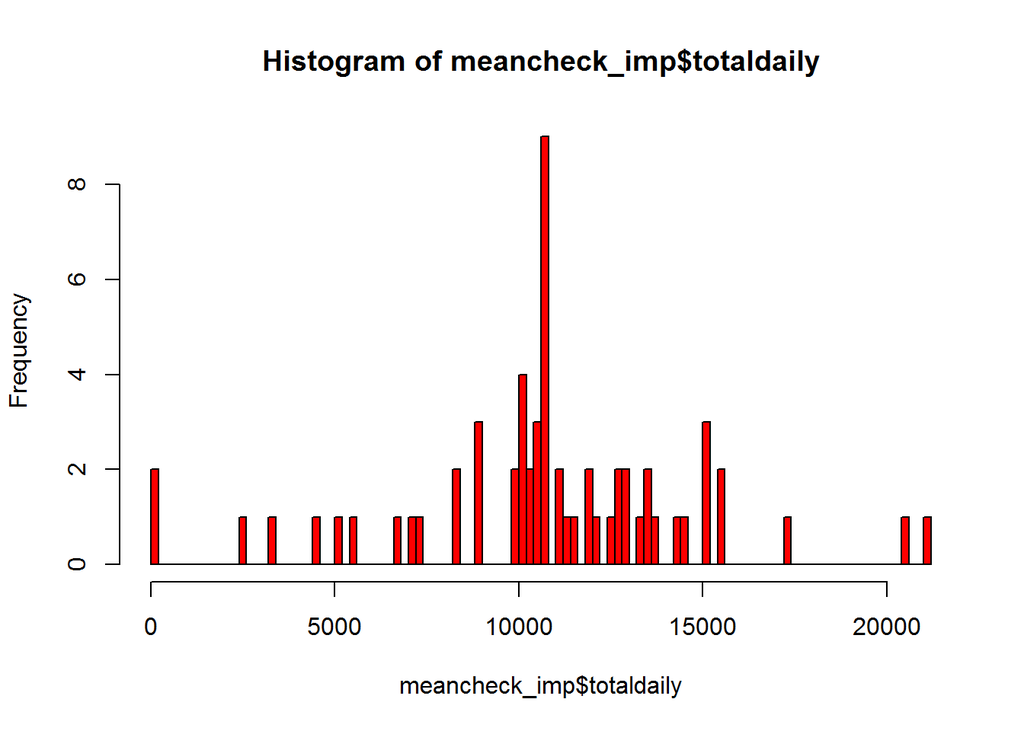

```r
meancheck_imp <- activity_impord %>%
  group_by(date) %>%
  summarise(totaldaily = sum(steps, na.rm=TRUE))

meancheck_imp$totaldaily <- as.numeric(meancheck_imp$totaldaily)
hist(meancheck_imp$totaldaily, breaks=100, col="red")
```

```r
mean_steps_imp <- meancheck_imp %>%
  summarise(mean_total = mean(totaldaily, na.rm=TRUE))
mean_steps_imp
```

```
## # A tibble: 1 x 1
##   mean_total
##        <dbl>
## 1   10766.19
```

```r
median_steps_imp <- meancheck_imp %>%
  summarise(median_total = median(totaldaily, na.rm=TRUE))
median_steps_imp
```

```
## # A tibble: 1 x 1
##   median_total
##          <dbl>
## 1     10766.19
```

## Difference between Weekdays and Weekends

First we need to add a variable that differentiates between weekends and weekdays.  
In this case, we will use a boolean flag.

```r
activity_impord %>%
  mutate(weekend = (weekdays(ymd(date))=="Saturday" | weekdays(ymd(date))=="Sunday")) %>%
  head()
```

```
##       steps       date interval weekend
## 1 1.7169811 2012-10-01        0   FALSE
## 2 0.3396226 2012-10-01        5   FALSE
## 3 0.1320755 2012-10-01       10   FALSE
## 4 0.1509434 2012-10-01       15   FALSE
## 5 0.0754717 2012-10-01       20   FALSE
## 6 2.0943396 2012-10-01       25   FALSE
```

Next we will create two separate data sets for weekends and weekdays using this flag.  
First for the weekends:

```r
int_wknd <- activity_impord %>%
  mutate(weekend = (weekdays(ymd(date))=="Saturday" | weekdays(ymd(date))=="Sunday")) %>%
  filter(weekend == TRUE) %>%
  group_by(interval) %>%
  summarise(totaldaily = mean(steps, na.rm=TRUE)) %>%
  print()
```

```
## # A tibble: 288 x 2
##    interval  totaldaily
##       <int>       <dbl>
## 1         0 0.214622642
## 2         5 0.042452830
## 3        10 0.016509434
## 4        15 0.018867925
## 5        20 0.009433962
## 6        25 3.511792453
## 7        30 0.066037736
## 8        35 0.108490566
## 9        40 0.000000000
## 10       45 0.558962264
## # ... with 278 more rows
```

Then for the weekdays:

```r
int_wkdy <- activity_impord %>%
  mutate(weekend = (weekdays(ymd(date))=="Saturday" | weekdays(ymd(date))=="Sunday")) %>%
  filter(weekend == FALSE) %>%
  group_by(interval) %>%
  summarise(totaldaily = mean(steps, na.rm=TRUE)) %>%
  print()
```

```
## # A tibble: 288 x 2
##    interval totaldaily
##       <int>      <dbl>
## 1         0 2.25115304
## 2         5 0.44528302
## 3        10 0.17316562
## 4        15 0.19790356
## 5        20 0.09895178
## 6        25 1.59035639
## 7        30 0.69266247
## 8        35 1.13794549
## 9        40 0.00000000
## 10       45 1.79622642
## # ... with 278 more rows
```

Finally lets visually compare them by plotting the time trends of both.

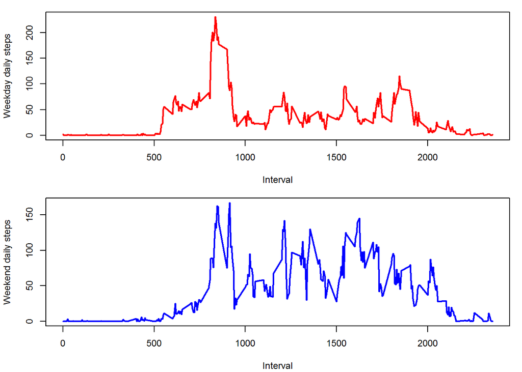

```r
par(mfrow=c(2,1),mar=c(4,4,1,1)+0.1, cex = 0.75)
plot(int_wkdy$interval, int_wkdy$totaldaily, type = "l",
     xlab="Interval", ylab="Weekday daily steps", col="red" , lwd=2)
plot(int_wknd$interval, int_wknd$totaldaily, type = "l",
     xlab="Interval", ylab="Weekend daily steps", col="blue" , lwd=2)
```

This is the end of the analysis.